# Kelly L. Sovacool

*Bioinformatician developing open source software*

Contact: sovacool [at] umich.edu

View a PDF version of my CV: https://sovacool.dev/latex-cv/vitae_KLS.pdf

## Skills

##### Programming Languages & Tools

Python

R

C++

Bash

Nextflow

Snakemake

git

GitHub

Quarto

R Markdown

Jupyter

LaTeX

conda/mamba/pixi

Docker

Singularity/Apptainer

SLURM

##### Software Development

Workflow management

Package maintenance

Test-driven development

Continuous integration

Documentation

Collaboration & peer review

High performance computing

AI-assisted development

##### Research

Reproducible research workflows

Supervised machine learning

Data visualization

Transcriptomics: bulk RNA-seq, single-cell RNA-seq

Genomics: WGS, exome-seq

Epigenomics: ChIP-seq, ATAC-seq, CUT&RUN

Microbiomics: gut microbiome composition, amplicon sequence analysis, metagenomics

## Education

| Dates | Degree | Institution |
| --- | --- | --- |
| 2018-2023 | PhD Bioinformatics | University of Michigan, Dept. of Computational Medicine and Bioinformatics Advisor: Patrick D. Schloss |
| 2014-2018 | BS Biology | University of Kentucky, Dept. of Biology Minor: Computer Science |

## Research Experience

[output not shown]

## Service

[output not shown]

## Teaching

[output not shown]

## Publications

[ORCID](https://orcid.org/0000-0003-3283-829X) [Google Scholar](https://scholar.google.com/citations?user=TlglgLgAAAAJ)

Last updated: October 14, 2026

* Indicates co-first author.

[output not shown]

## Presentations

### Talks

[output not shown]

### Posters

| Date | Title | Event | Location |
| --- | --- | --- | --- |
| Jul 2026 | [Anatomy of a modular toolchain for reproducible bioinformatics workflows](https://github.com/CCBR/reproducible-toolchain) | ISMB BOSC 2026 | Washington, DC |
| Jun 2022 | Predicting the severity of *C. difficile* infections from the taxonomic composition of the gut microbiome | ASM Microbe | Washington, DC |
| Jun 2020 | OptiFit: a fast method for fitting amplicon sequences to existing OTUs | ASM Microbe | Virtual |
| Apr 2018 | Developing a Global Homology Analysis for Comparative Genomics | Showcase for Undergraduate Scholars | University of Kentucky |
| Apr 2018 | Developing a Global Homology Analysis for Comparative Genomics | National Conference on Undergraduate Research | University of Central Oklahoma |
| Apr 2016 | Processing RNA-seq Reads of Plants Infected with the Coffee Ringspot Virus | Showcase for Undergraduate Scholars | University of Kentucky |
| Apr 2016 | Processing RNA-seq Reads of Plants Infected with the Coffee Ringspot Virus | UT-KBRIN Bioinformatics Summit | Cadiz, KY |
| Apr 2015 | The Effect of Meditation on Performance | Showcase for Undergraduate Scholars | University of Kentucky |

## Awards

### Grants

| Dates | Title | Institution | Amount |
| --- | --- | --- | --- |
| 2022 | Conference Travel Grant | Rackham Graduate School University of Michigan | $900 |
| 2020-2021 | Rackham Interdisciplinary Workshop Grant | Rackham Graduate School University of Michigan | $500 |
| 2020 | Conference Travel Grant | Rackham Graduate School University of Michigan | $800 |
| 2019-2020 | Rackham Interdisciplinary Workshop Grant | Rackham Graduate School University of Michigan | $500 |
| 2019-2021 | NIH T32 Bioinformatics Training Program Fellow | Bioinformatics Graduate Program University of Michigan |  |
| 2017 | Oswald Research & Creativity Award 2nd place in Biological Sciences | Office of Undergraduate Research University of Kentucky | $200 |
| 2017 | Summer Research Grant | Office of Undergraduate Research University of Kentucky | $2,000 |
| 2014-2018 | Presidential Scholarship | University of Kentucky | out-of-state full tuition |

### Honors

| Dates | Title | Institution |
| --- | --- | --- |
| 2018 | Graduated Cum Laude with Departmental Honors in Biology | University of Kentucky |
| 2018 | Biology Undergraduate Research Award Nominee | University of Kentucky |
| 2014-2018 | Lewis Honors College | University of Kentucky |

## Open Source Contributions

[figure not shown]

##### CCBR pipeliner

software

nextfow

snakemake

cancer research

Suite of pipelines for multi-omics data analysis, purpose-built for NCI researchers

|  | Co-author and maintainer |
| --- | --- |

[figure not shown]

##### mikropml

software

machine learning

R

User-Friendly R Package for Supervised Machine Learning Pipelines

|  | Co-author and maintainer |
| --- | --- |

[figure not shown]

##### schtools

software

microbiome

R

Schloss Lab tools for reproducible microbiome research

|  | Co-author and maintainer |
| --- | --- |

[figure not shown]

##### mikropml snakemake workflow

software

snakemake

machine learning

R

Python

Snakemake template for building reusable and scalable machine learning pipelines with mikropml

|  | Co-author and maintainer |
| --- | --- |

[figure not shown]

##### mothur

software

microbiome

C++

Command-line tool for processing microbial amplicon sequence data

|  | Contributor |
| --- | --- |

[figure not shown]

##### mothur snakemake workflow

software

microbiome

snakemake

R

Python

Snakemake template for reproducible microbial amplicon sequence analysis with mothur

|  | Co-author |
| --- | --- |

[figure not shown]

##### U-M Software Carpentry

Curriculum

R

Unix Shell

git

Workshop

Intro to R, the Unix shell, and git for workshops on reproducible research.

|  | Co-author and maintainer |
| --- | --- |

[figure not shown]

##### Girls Who Code at U-M DCMB

Curriculum

Python

Data Science

Intro to Python for Data Science via Live-Coding for Girls Who Code clubs.

|  | Co-author and maintainer |
| --- | --- |

[figure not shown]

##### Code Clubs

Code Club

Tutorials

Short coding tutorials for lab meetings

|  | Contributor |
| --- | --- |

[figure not shown]

##### U-M DANG!

Reproducibility

Tutorials

repro-packs: Organizing projects for reproducibility and headache prevention.

|  | Author |
| --- | --- |

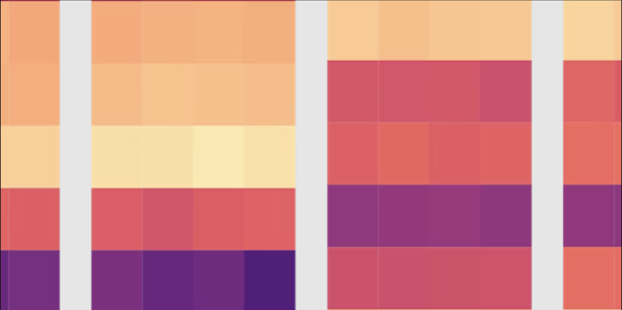

##### Intro to R & RNA-seq

Curriculum

R

RNA-seq

Workshop

Workshop for 2022 ASM Microbe attendees

|  | Contributor |
| --- | --- |

## Continuing Education

| Date | Title | Organization | Location |
| --- | --- | --- | --- |
| Jul 2026 | MolSSI AI-Assisted Development Best Practices Workshop | Molecular Sciences Software Institute | virtual |
| Jan 2020 | Building Tidy Tools workshop at rstudio::conf | Rstudio, PBC | San Francisco, CA |
| Dec 2019 | Winter School in Research Software Engineering | US Research Software Sustainability Institute | Seattle, WA |
| Jun 2019 | Software Carpentry Instructor Training | The Carpentries | University of Michigan |
| May 2019 | PyCon Education Summit & Conference | The Python Software Foundation | Cleveland, OH |
| Apr 2019 | MICROBIOL 612.2 | Riffomonas Minimal R Workshop | University of Michigan |